# esm206_lab5

Russell Fager

10/25/2021

```r
knitr::opts_chunk$set(echo = TRUE, message = FALSE, warning = FALSE)
library(tidyverse)
library(effsize)
```

## Part 1: Confidence intervals

In this section we wil use the `t.test()` function to calculate confidence intervals.

### Example 1

Create a single mock sample containing a number of values, then learn to use `t.test()` to return confidence intervals, and learn about in-line code referencing so our text become more reproducible, too.

```r
# Create a mock sample

otter_lengths <- c(30, 45, 28, 31, 34, 46, 52, 29)

# Find the confidence interval

otter_ci<-t.test(otter_lengths)

# find standard deviation

otter_sd<-sd(otter_lengths)
```

if we took multiple samples from the population and calculated a confidence interval for each we would expect 95% of those intervals to have the population mean.

Mean otter length is 36.9 inches $\pm$ 9.3 (mean $\pm$ sd, n=8) with a 95% confidence interval of [29.1, 44.7] inches.

#### Now, using in-line referencing

Mean otter length is 36.9 inches with a 95% confidence interval of [29.1, 44.7] inches.

## Part 2: Two sample t-tests

### Example 1

Make two mock samples and ask the question: do we have sufficient evidence to make us reject the null hypothesis that these samples were drawn from populations with the same mean?

```r
# make my mock samples

oak_trees <- c(20, 19, 24, 28, 34, 12, 15, 25)

pine_trees <- c(39, 26, 20, 30, 37, 22, 19, 18)

# Two-sample t-test
tree_t <- t.test(oak_trees, pine_trees)

#null hyopthesis: mean heights are the same

#i.e: trees are drawn from populations with the same mean height
```

if these are drawn from populations of the same mean height, there’s a 28.7% chance of taking a random samples from each population and finding the same mean by chance. i.e: 30 out of 100 times I could get results that are at least this different.

## Part 3: another t-test with cars data

using the `mpg` data set

### Take a look at the data

```r
compact_suv <- mpg %>%
  filter(class %in% c("compact", "suv"))

#check for remaining levels(
  unique(compact_suv$class)
```

```
## [1] "compact" "suv"
```

Create a histogram of city mileage (cty) faceted by class starting from compact_suv.

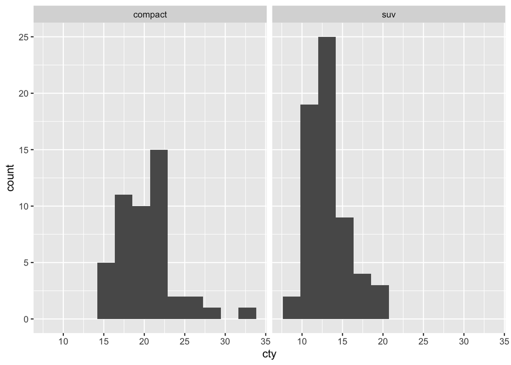

```r
ggplot(data = compact_suv, aes(x = cty))+
  geom_histogram(bins = 12) +
  facet_wrap(~class)
```

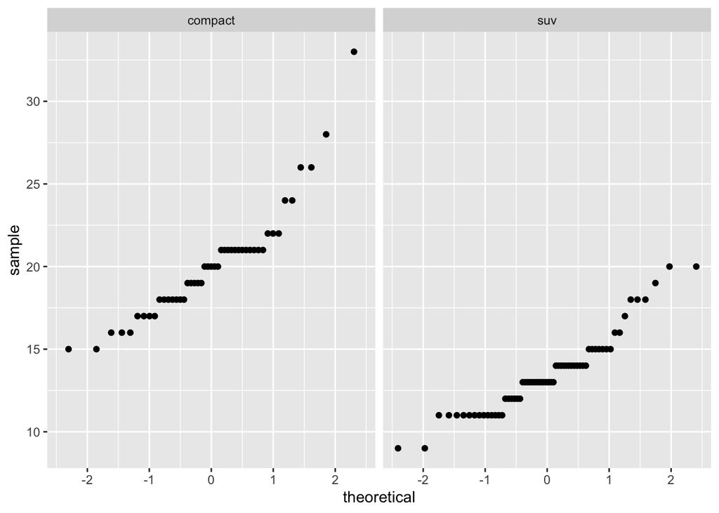

```r
ggplot(data = compact_suv, aes(sample = cty)) +
geom_qq() +
  facet_wrap(~ class)
```

find some summary statistics for each group

```r
car_stats <- compact_suv %>%
  group_by(class) %>%
  summarize(
    mean_city = round(mean(cty), 2),
    sd_city = round(sd(cty), 2),
    sample_size = n()
  )

car_stats
```

```
## # A tibble: 2 × 4
##   class   mean_city sd_city sample_size
##   <chr>       <dbl>   <dbl>       <int>
## 1 compact      20.1    3.39          47
## 2 suv          13.5    2.42          62
```

the t.test() function really wants vectors of things. Use the `pull()` function to pull out a vector from a data frame.

```r
compact_sample <- compact_suv %>%
  filter(class == "compact") %>%
  pull(cty)
```

```r
suv_sample <- compact_suv %>%
  filter(class == "suv") %>%
  pull(cty)
```

mean city gas mileages for suvs and compact cars are the same = null hypothesis

```r
t.test(compact_sample, suv_sample)
```

```
##
##  Welch Two Sample t-test
##
## data:  compact_sample and suv_sample
## t = 11.393, df = 79.558, p-value < 2.2e-16
## alternative hypothesis: true difference in means is not equal to 0
## 95 percent confidence interval:
##  5.469914 7.785405
## sample estimates:
## mean of x mean of y
##  20.12766  13.50000
```